# IDS Group Project

by The Ravens: Maisie Byrne, Julia Toma, Elanna Goldie, & Raven Callaghan

2023-11-29

[output not shown]

## Our Research Question & Why it’s of Interest

We are looking at the number of crimes committed within prisons by different age groups and sexes, and at prisons of different security levels. We have looked at the proportion of crimes committed that are violent, to see if there is a correlation between committing violent crimes and re-offending. Essentially, our question is do those who have a tendency towards violence have a stronger tendency to commit crime in general?

We consider this question to be of interest because violence in prisons is an obvious issue. Prisons should exist for the purpose of rehabilitation; violence in prisons threatens the ability of the institutions to support vulnerable prison members and lead people to a life free of crime after their sentence. Violence in prisons also threatens prison staff. Persistent and large scale crime within prisons requires a greater number of staff, which takes valuable financial resources away from other spending opportunities that would benefit prisoners and staff to a greater extent.

In theory, knowing which age group etc. is the most likely to commit crime and more specially, violent crime, would help prisons mitigate the problem e.g. by housing prisoners in mixed age accommodation etc. For security, we would expect prisons of a higher security to have a higher rate of violence but perhaps a lower rate of crime because of a greater number of staff.

## Our Data set

Ministry of Justice, 28th July 2022, CSV data set and variable guide: Adjudications Q1 2022, electronic data set, Viewed 20th October 2023, https://www.gov.uk/government/statistics/offender-management-statistics-quarterly-january-to-march-2022

The key variables we are looking at are Age Group, Offence, Count, Sex and Predominant function of establishment.

Offence is a categorical variable that says the offence committed by a singular prisoner whilst in prison.

Count is a numerical variable that gives the number of times that a prisoner committed the same offence.

Predominant Function of Establishment is a categorical variable that tells u the security rating of the prison. There is category A (high security), B (local and training prisons), C (training and resettlement), D (open prisons), Female, Local, Young Offender Institution (YOI) and Youth Justice Board.

## Findings

We started by looking at some initial summary statistics. We looked at the average amount of times a prisoner would repeat the same offence for the different age groups. Our results were as follows: Mean for 18-20 year olds = 1.89 Mean for 21-24 year olds = 1.69 Mean for 25-29 year olds = 1.81 Mean for 30-39 year old = 2.13 Mean for 40-49 year old = 1.70

To look at the data further, we then created some visualisations. We created a bar graph for each prison type showing the overall number of offences committed by each age group.

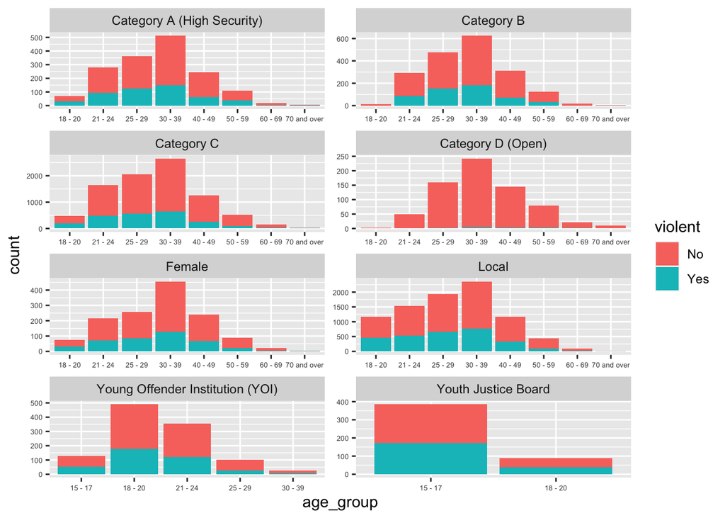

We found that non-violent crimes make up the majority of crimes committed.

We then set out to create a model that would predict how many times someone will commit a crime in prison based on their age, gender, type of prison they are in.

## Creating new variables

The Adjudications Q1 2022 dataset does specify specifically if crimes are violent or not, it simply details the legal name of the offence committed, e.g. wilful damage, so we used the mutate function to create a new variable, ‘violent’, which split the offences into violent and nonviolent crimes. In hindsight, we perhaps shouldn’t have included wilful damage as a violent crime, considering it means damage to property, whereas a violent crime is typically defined as one which involves violence against a person, or robbery. It is also in this phase that we created the variable ‘reoffender.’ We created this as a binary variable where reoffender = 1 when a prisoner had committed an offence more than once and reoffender = 0 when a prisoner had committed an offence only once. These two variables, violence and reoffender, were to be the basis of our model.

## The model

As a group we recognised that our data was predominantly categorical. It would have been impractical and difficult to coerce the data into a manner where a linear regression model to predict the outcome of a response variable, therefore we chose to implement a generalised linear model instead. This type of model uses logistic regression, which has the ability to take the values of numerous categorical variables and use those to assign a probability that the response variable being measured will be true or false.

This is done by implementing a workflow for our model, which consisted of a recipe and the model itself. The purpose of the recipe was to ensure that dummy variables were assigned for all of the variables (age group, sex, establishment type, religion and the violent nature of the crime). This process was made seamless by the prior manipulation of the model data where we coerced the categorical data types as factors, which were then relevelled for the purposes of data tidiness.

One example of the models we made had the following values: Model 1, reoffender & violence intercept = -0.9971 coefficient = 0.3850

Finally, to check the efficacy of our models, we plotted receiver operating characteristic (ROC) curves, which plots the false positive rate against the true positive rate. Broadly speaking, a larger area under the curve corresponds to a stronger correlation between the predictive variables used and the outcome of the response variables. The area under the curves alongside the predictors and outcomes used can be found below:

Model 1 (Reoffender ~ Violence) 0.462

Model 2 (Reoffender ~ Violence, Age, Sex, Establishment Type, Religion) 0.379

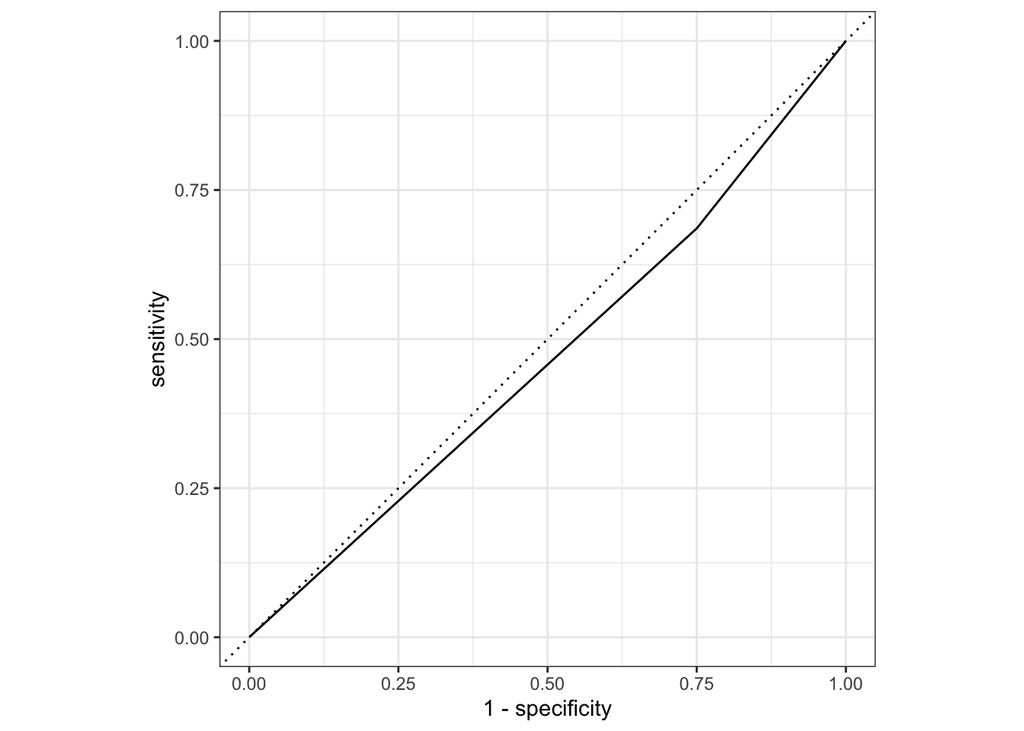

Model 3 (Reoffender ~ Establishment Type) 0.475 Model 4 (Reoffender ~ Sex, Violent) 0.502

This was, of course, not the outcome we’d hoped for when starting this investigation, though we understand it can be the nature of looking at real data sets.

We considered that we possibly went into this investigation with assumptions about correlation that did not actually exist.

## References

Definition of violence - Merriam-Webster Dictionary - https://www.merriam-webster.com/dictionary/violence

Obtained code for modifying axis text size for first visualisations - https://ggplot2.tidyverse.org/articles/faq-customising.html#:~:text=in%20theme()%20.-,In%20both%20cases%2C%20set%20font%20size%20in%20the%20size%20argument,title.

Ministry of Justice, 28th July 2022, CSV data set and variable guide: Adjudications Q1 2022, electronic data set, Viewed 20th October 2023, https://www.gov.uk/government/statistics/offender-management-statistics-quarterly-january-to-march-2022